# Approximation of the distribution function

Dongjie

2020/3/27

# Abstract

This is a report to complete approximation of the distribution fuction of $N(0,1)$ by the Monte Carlo methods. **keywords:** Monte Carlo methods, Standard Normal Distribution

# 1. Introduction

This is a report to complete approximation of the distribution fuction of N(0,1) by the Monte Carlo methods. In order to demonstrate the process of approximation,I made a table of true values and drawn some box plots. Finally,we can draw an conclude that as n gets bigger and bigger,approximation of the distribution function is getting closer and closer to the truth value.

# 2. Math Equations

This report will use the following math equations.

1. The distribution function of $N(0,1)$:

$$\begin{equation}
\Phi(t) = \int_{-\infty}^t \frac{1}{\sqrt{2\pi}} e^{\frac{-y^2}{2}} dy
\end{equation}$$

2. The Monte Carlo methods:

$$\begin{equation}
\hat\Phi(t) = \frac{1}{n} \sum_{i=1}^n I(X_i \le t),
\end{equation}$$

where $X_i$’s are a random sample from $N(0, 1)$, and $I(\cdot)$ is the indicator function.

# 3. Analysis

This experiment chooses some random samples of different sizes ($n\in\{10^2, 10^3, 10^4\}$) and some kinds of t ($t\in\{0.0,0.67,0.84,1.28,1.65,2.32,2.58,3.09,3.72\}$) to estimate the approximation of the distribution function of $N(0,1)$ .

## 3.1 The true value for comparison

The following table is produced which includes the true value for comparison of only one experiment.

the True Value for Comparison

[output not shown]

## 3.2 Repeat the experiment 100 times

To better compare the errors between the results of Monte Carlo simulation and the true value, the best way is to repeat the experiment 100 times.

### 3.2.1 the box plot of the 100 approximation errors (n=100)

.

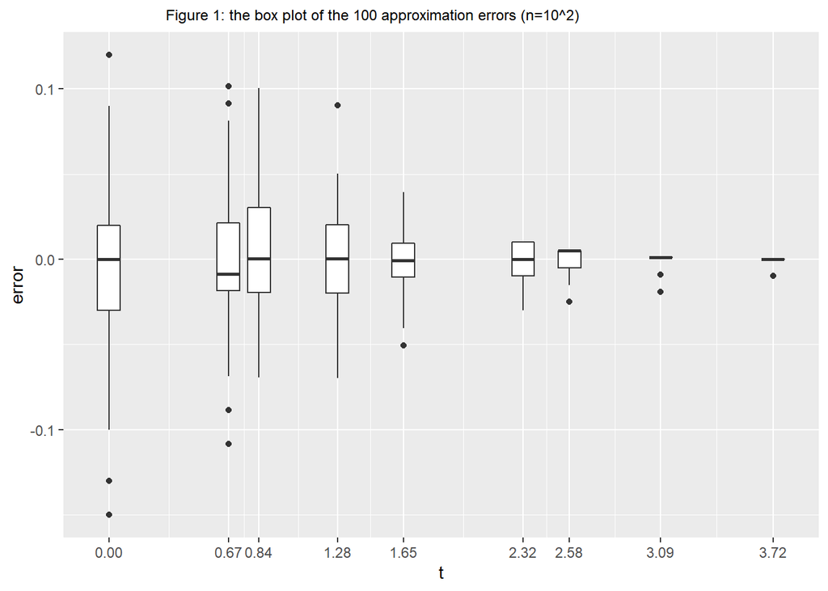

### 3.2.2 the box plot of the 100 approximation errors (n=1000)

.

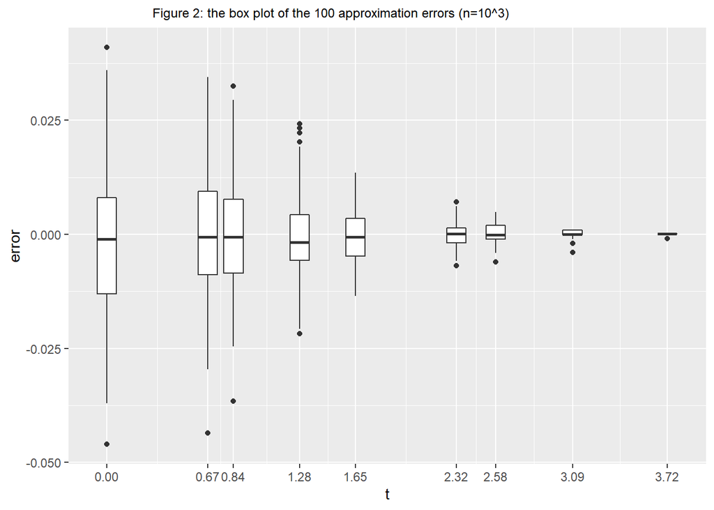

### 3.2.3 the box plot of the 100 approximation errors (n=10000)

.

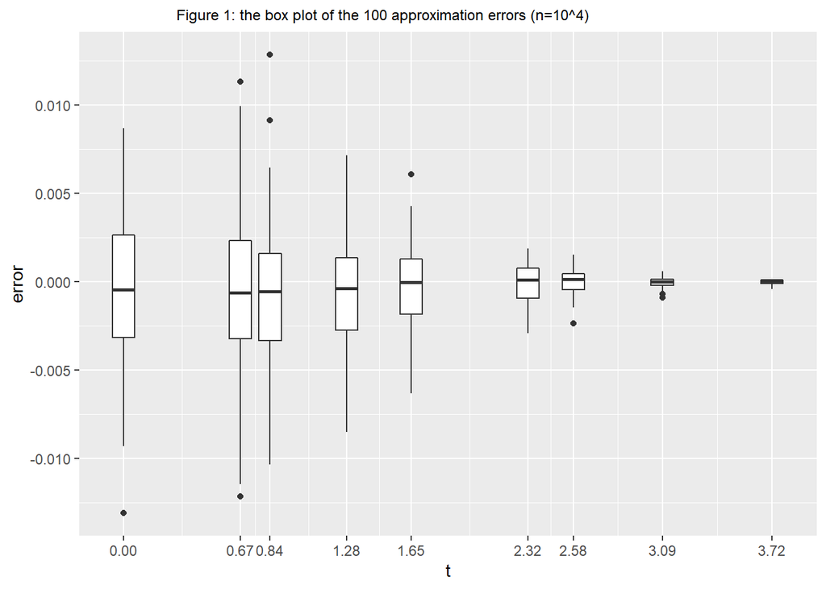

# 4. Conclusion

In conclusion, we can draw an conclude that as n gets bigger and bigger,approximation of the distribution function is getting closer and closer to the truth value.